# project_two

## Introduction

Recommendation systems have becom the primary method for people to discovery new music. While these systems offer unpararlleled convenience, they don't always accurately capture individual preferences. Platforms like Spotify have recently integreated AI features that allow users to recive curated playlists from input prompts. As these algorithms grow more sophisticated, important questions about their impact on listeners emerge.

While algorithms effectively recommend similar music, they don't always feel right intuitively with listeners — a phenomenon known as the 'vibe gap'.

This project aims to explore the metadata featuers that a company might use to power their recommendation systems. More importantly, I want to investigate how recommendation systems might navigate the "uncanny valley" of music curation—the uncomfortable space where suggestions feel almost right but miss the mark. My central question is: How can these systems assist users in discovering music without overly controlling or constraining their tastes?

By using a Random Forest classification model to predict target genres, I will seek to identify pathways toward intelligent recommendation systems that serve to enhance rather than dicate musical discovery.

```python
# import statements
import pandas as pd
import sklearn as sk
import numpy as np
import matplotlib.pyplot as plt
import seaborn as sns

from sklearn.model_selection import train_test_split
from sklearn.ensemble import RandomForestClassifier
from sklearn.metrics import classification_report
from sklearn.metrics import confusion_matrix
```

I found this data on datacamp.com I chose it because it contains data on song features as well as genre. The features include title, artist, genre, year, as well as various features describing song metadata, like bpm, acousticness, and energy.

```python
df = pd.read_csv('spotify_top_music_download.csv')
df.head()
```

|  | title | artist | top genre | year | bpm | nrgy | dnce | dB | live | val | dur | acous | spch | pop |
| --- | --- | --- | --- | --- | --- | --- | --- | --- | --- | --- | --- | --- | --- | --- |
| 0 | Hey, Soul Sister | Train | neo mellow | 2010 | 97 | 89 | 67 | -4 | 8 | 80 | 217 | 19 | 4 | 83 |
| 1 | Love The Way You Lie | Eminem | detroit hip hop | 2010 | 87 | 93 | 75 | -5 | 52 | 64 | 263 | 24 | 23 | 82 |
| 2 | TiK ToK | Kesha | dance pop | 2010 | 120 | 84 | 76 | -3 | 29 | 71 | 200 | 10 | 14 | 80 |
| 3 | Bad Romance | Lady Gaga | dance pop | 2010 | 119 | 92 | 70 | -4 | 8 | 71 | 295 | 0 | 4 | 79 |
| 4 | Just the Way You Are | Bruno Mars | pop | 2010 | 109 | 84 | 64 | -5 | 9 | 43 | 221 | 2 | 4 | 78 |

```python
df.shape
```

```
(603, 14)
```

```python
df.info
```

```
<bound method DataFrame.info of                                                  title            artist  \
0                                     Hey, Soul Sister             Train
1                                 Love The Way You Lie            Eminem
2                                              TiK ToK             Kesha
3                                          Bad Romance         Lady Gaga
4                                 Just the Way You Are        Bruno Mars
..                                                 ...               ...
598                Find U Again (feat. Camila Cabello)       Mark Ronson
599      Cross Me (feat. Chance the Rapper & PnB Rock)        Ed Sheeran
600  No Brainer (feat. Justin Bieber, Chance the Ra...         DJ Khaled
601    Nothing Breaks Like a Heart (feat. Miley Cyrus)       Mark Ronson
602                                   Kills You Slowly  The Chainsmokers

           top genre  year  bpm  nrgy  dnce  dB  live  val  dur  acous  spch  \
0         neo mellow  2010   97    89    67  -4     8   80  217     19     4
```

[output cut: 25 more lines]

```python
df.isnull().sum()
```

```
title        0
artist       0
top genre    0
year         0
bpm          0
nrgy         0
dnce         0
dB           0
live         0
val          0
dur          0
acous        0
spch         0
pop          0
dtype: int64
```

This dataset contains no null values, so I won't have to drop any rows due to nulls. However, I don't need some features, such as artist, so I'll drop those. I'll also rename so columns for readability

```python
df.drop(['title', 'artist', 'pop'], axis=1, inplace=True)
columns = ['genre', 'year', 'bpm', 'energy', 'danceability', 'loudness', 'liveness', 'valence', 'length', 'acousticness', 'speechiness']
df.columns = columns
df.head()
```

|  | genre | year | bpm | energy | danceability | loudness | liveness | valence | length | acousticness | speechiness |
| --- | --- | --- | --- | --- | --- | --- | --- | --- | --- | --- | --- |
| 0 | neo mellow | 2010 | 97 | 89 | 67 | -4 | 8 | 80 | 217 | 19 | 4 |
| 1 | detroit hip hop | 2010 | 87 | 93 | 75 | -5 | 52 | 64 | 263 | 24 | 23 |
| 2 | dance pop | 2010 | 120 | 84 | 76 | -3 | 29 | 71 | 200 | 10 | 14 |
| 3 | dance pop | 2010 | 119 | 92 | 70 | -4 | 8 | 71 | 295 | 0 | 4 |
| 4 | pop | 2010 | 109 | 84 | 64 | -5 | 9 | 43 | 221 | 2 | 4 |

```python
for col in df.columns:

    print(df[col].value_counts())
```

```
genre
dance pop                    327
pop                           60
canadian pop                  34
barbadian pop                 15
boy band                      15
electropop                    13
british soul                  11
big room                      10
canadian contemporary r&b      9
neo mellow                     9
art pop                        8
complextro                     6
australian dance               6
hip pop                        6
australian pop                 5
atl hip hop                    5
edm                            5
permanent wave                 4
latin                          4
hip hop                        4
colombian pop                  3
tropical house                 3
escape room                    2
acoustic pop                   2
indie pop                      2
detroit hip hop                2
candy pop                      2
downtempo                      2
brostep                        2
electronic trap                2
folk-pop                       2
baroque pop                    2
electro                        2
canadian hip hop               2
belgian edm                    2
chicago rap                    1
house                          1
hollywood                      1
metropopolis                   1
```

[output cut: 157 more lines]

```
33      2
38      2
20      2
31      2
25      2
26      2
28      2
44      2
45      1
32      1
48      1
42      1
0       1
35      1
Name: count, dtype: int64
```

This data is heavily skewed towards pop genres. This is most likely due to the fact that this dataset compiles popular songs, and pop is one of the most popular genres. To reduce the class imbalance, which can make the model less accurate, I'll group the set into a few genres.

```python
genre_mapping = {
    'dance pop': 'pop',
    'pop': 'pop',
    'canadian pop': 'pop',
    'barbadian pop': 'pop',
    'boy band': 'pop',
    'australian pop': 'pop',
    'art pop': 'pop',
    'colombian pop': 'pop',
    'acoustic pop': 'pop',
    'candy pop': 'pop',
    'danish pop': 'pop',
    'moroccan pop': 'pop',
    'baroque pop': 'pop',
    'french indie pop': 'pop',

    'canadian contemporary r&b': 'r&b/hiphop',
    'atl hip hop': 'r&b/hiphop',
    'hip pop': 'r&b/hiphop',
    'british soul': 'r&b/hiphop',
    'hip hop': 'r&b/hiphop',
    'detroit hip hop': 'r&b/hiphop',
    'canadian hip hop': 'r&b/hiphop',
    'chicago rap': 'r&b/hiphop',
    'australian hip hop': 'r&b/hiphop',
    'alternative r&b': 'r&b/hiphop',

    'electropop': 'edm',
    'big room': 'edm',
    'complextro': 'edm',
    'australian dance': 'edm',
    'edm': 'edm',
    'tropical house': 'edm',
    'electro': 'edm',
    'electronic trap': 'edm',
    'belgian edm': 'edm',
    'brostep': 'edm',
    'house': 'edm',
    'electro house': 'edm',

    'neo mellow': 'alternative',
    'permanent wave': 'alternative',
    'escape room': 'alternative',
    'indie pop': 'alternative',
    'folk-pop': 'alternative',
    'downtempo': 'alternative',
    'alaska indie': 'alternative',
    'celtic rock': 'alternative',
    'metropopolis': 'alternative',
    'irish singer-songwriter': 'alternative',
    'hollywood': 'alternative',

    'latin': 'latin',
    'canadian latin': 'latin',
    'contemporary country': 'country',
}

df['genre_grouped'] = df['genre'].replace(genre_mapping)
df['genre_grouped'].value_counts()
```

```
genre_grouped
pop            476
edm             53
r&b/hiphop      42
alternative     26
latin            5
country          1
Name: count, dtype: int64
```

```python
allowed = ['alternative', 'edm', 'r&b/hiphop', 'pop']
print(df[~df['genre_grouped'].isin(allowed)])
```

```
                    genre  year  bpm  energy  danceability  loudness  \
440                 latin  2016  186      81            70        -3
441        canadian latin  2016   98      47            80       -10
461                 latin  2017  178      82            65        -4
536  contemporary country  2018   86      59            47        -6
550                 latin  2018  105      72            76        -6
597                 latin  2019   94      87            74        -3

     liveness  valence  length  acousticness  speechiness genre_grouped
440        37       69     225             9            7         latin
441         7       69     228            25            4         latin
461        10       82     229            23           17         latin
536        13       50     196             3            3       country
550        23       47     210             2            8         latin
597         4       61     181            17            5         latin
```

Since latin and country are such small classes, I'll drop them in order to have better defined classes.

```python
df = df[~df['genre_grouped'].isin(['latin', 'country'])]
df.drop(['genre'], axis=1, inplace=True)
df['genre_grouped'].value_counts()
```

```
genre_grouped
pop            476
edm             53
r&b/hiphop      42
alternative     26
Name: count, dtype: int64
```

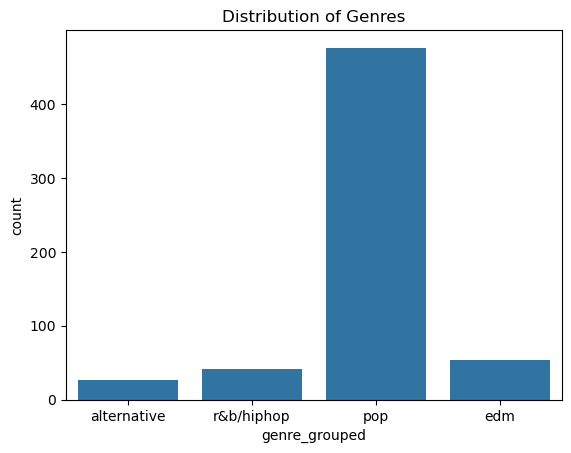

```python
sns.countplot(x='genre_grouped', data=df)
plt.title("Distribution of Genres")
plt.show()
```

Even after grouping, pop is has much more data points than the other genres.

Now that the data has been preprocessed, we can begin preparing for model training! Since the datatype of genre is currently a string, I'll convert the genres to integers.

```python
mapping = {'alternative': 0, 'edm': 1, 'r&b/hiphop': 2, 'pop': 3}
df['genre_label'] = df['genre_grouped'].map(mapping)
df.head()

# Declaring feature and target variables
X = df.drop(['genre_grouped', 'genre_label'], axis=1)
y = df['genre_label']

# Splitting the dataset into training and testing sets
X_train, X_test, y_train, y_test = train_test_split(X, y, test_size = 0.2, random_state = 42)
```

I will be using a Random Forest classifier because it is flexible and a good indicator of feature importance. It works by generating multiple randomly created decision trees, then combines their outputs into a majority vote to make a final decision. While Random Forest models are robust and are resitant to overfitting, they come with a trade off: the tree making and predicting process is computationally intensive and time consuming.

```python
# instantiate the classifier

rfc = RandomForestClassifier(n_estimators=100, random_state=42)

# fit the model

rfc.fit(X_train, y_train)


# Predict the Test set results

y_pred = rfc.predict(X_test)


# Check accuracy score
print(classification_report(y_test, y_pred))
```

```
              precision    recall  f1-score   support

           0       1.00      0.20      0.33         5
           1       1.00      0.14      0.25         7
           2       0.00      0.00      0.00         7
           3       0.86      1.00      0.92       101

    accuracy                           0.86       120
   macro avg       0.71      0.34      0.38       120
weighted avg       0.82      0.86      0.80       120
```

The model's overall accuracy on the test set is .86 (103/120 correct). My model had a perfect precision on alternative and edm, a high precision with pop, but a score of 0 for both precision and recall for r&b/hiphop. However, this single number is misleaidng beacause my datset is heavily imbalanced, with pop having 101 of 120 of the test samples. As a result, the classifier predicts most cases as pop. In addition, r&b/hiphop songs may be sonically more similar to pop than edm or alternative, which may make it more difficult for the model to dicern between classes. This is a major limitation of my dataset, as the accuracy of the model would increase with more data points and being more balanced.

Now, let's do some visualization

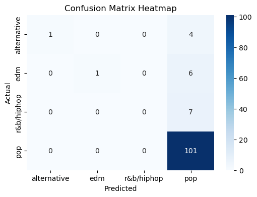

```python
cm = confusion_matrix(y_test, y_pred)

labels = ['alternative', 'edm', 'r&b/hiphop', 'pop']

plt.figure(figsize=(6,4))
sns.heatmap(cm, annot=True, fmt='d', cmap='Blues', xticklabels=labels, yticklabels=labels)

plt.xlabel('Predicted')
plt.ylabel('Actual')
plt.title('Confusion Matrix Heatmap')
plt.show()
```

We can see from this confusion matrix that the model was very good at predicting pop, with 101 samples being correctly predicted as pop. All 7 of the r&b/hiphop samples were classified as pop, which adds evidence to the idea that r&b/hiphop songs have more similar sonic attributes than alternative or edm, making it difficult for the model to distinguish between the two classes.

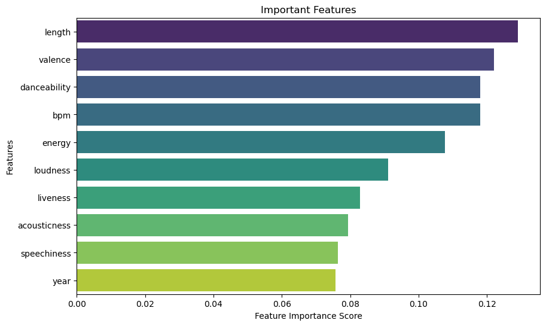

```python
importances = rfc.feature_importances_
features = X.columns

# Put into a DataFrame for plotting
feat_importances = pd.DataFrame({'Feature': features, 'Importance': importances})

# Sort values
feat_importances = feat_importances.sort_values(by='Importance', ascending=False)

# Plot
plt.figure(figsize=(10,6))
sns.barplot(x="Importance", y="Feature", data=feat_importances, palette="viridis")

plt.xlabel("Feature Importance Score")
plt.ylabel("Features")
plt.title("Important Features")
plt.show()
```

My model is treating all of the features with similar importance. However, length is the most important feature, which is surprising, as I would expect that some of the less important features, like acousticness would have been more important. This could be due to length being less noisy than other features.

### Discussion

While my model did not perform as accurately as ideally desired, I learned several important insights in this project. Firstly, it is easier for a classification model to identify common patterns than it is to classify outliers. In the context of music recommendation systems, this can manifest in the aforementioned "vibe gap", in which a recommendation system tends to recommended similar music in terms of sonic qualities, rather than what is likely to feel right to a listener.

A major limitation of my dataset was that the data was highly imbalanced, and some genres were represented by very few samples. While a streaming platform has the means to collect larger and more varied data, music is naturally unbalanced, and it may be more difficult to accurately train a model to predict smaller genres. This may lead to users who listen to popular music finding apt recommendations while users who have more niche tastes feeling underserved.

Despite these challenges, I was able to find out some answers to my questions, such as the factors that go into recommendation. I feel that more exploration is needed, especially with a larger dataset, to understand how a recommendation system could better cater to a variety of musical tastes.

Music recommendation has a significant social impact. Music is an important part of people's emotional lives, and recommendation systems play a direct role in how a person listens to music. In this project, I group many different kinds of genres, which came from only the most popular songs on Spotify. This is a very generalized and narrow view of the music world, and someone reading this project may feel that their preferred genres are seemingly less important than others in music recommendation systems. Positively, I feel that this project can help people understand the algorithms that they interact with daily, and raise awareness of how imporvements in these systems can help serve diverse emotional and musical tastes.

References

https://www.kaggle.com/code/prashant111/random-forest-classifier-tutorial

https://www.datacamp.com/datalab/datasets/dataset-r-spotify-music